# Python'da 1D Numpy

# Python'da 1D Numpy

## Maqsadlar

Ushbu amaliyotni tugatgandan so‘ng, siz quyidagilarni bajara olasiz:

- `numpy` kutubxonasini chaqirish (import) va ishlatish
- `numpy` yordamida amallarni bajarish

## Mundarija

- Numpy nima?
  - Turi (Type)
  - Qiymat berish
  - Qirqish (Slicing)
  - Ro‘yxat yordamida qiymat berish
  - Boshqa atributlar
- Numpy massivlari ustida amallar
  - Massivlarni qo‘shish
  - Massivlarni ko‘paytirish
  - Ikki Numpy massivining ko‘paytmasi
  - Nuqtali ko‘paytma (Dot Product)
  - Numpy massiviga konstanta qo‘shish
- Matematik funksiyalar
- Linspace

## Numpy nima?

NumPy — bu massivlar, chiziqli algebra, Fure almashtirishlari va matritsalar bilan ishlash uchun mo‘ljallangan Python kutubxonasi. NumPy «Numerical Python» (Raqamli Python) degan ma'noni anglatadi va u ochiq manbali loyihadir. NumPy ichidagi massiv obyekti **ndarray** deb ataladi va u ndarray bilan ishlashni osonlashtiruvchi ko‘plab yordamchi funksiyalarni taqdim etadi.

Massivlar ma'lumotlar fani sohasida juda tez-tez ishlatiladi, chunki bu sohada tezlik va resurslar juda muhim ahamiyatga ega.

NumPy odatda `np` taxallusi (alias) ostida chaqiriladi.

U odatda o‘zgarmas o‘lchamga ega bo‘ladi va uning har bir elementi bir xil turdagi ma'lumotdan iborat bo‘ladi. Biz avval `numpy` ni chaqirib, so‘ngra ro‘yxatni (list) numpy massiviga aylantirishimiz mumkin:

```python
# numpy kutubxonasini chaqiramiz

import numpy as np
```

So‘ngra ro‘yxatni quyidagicha massivga aylantiramiz:

```python
# numpy massivini yaratamiz

a = np.array([0, 1, 2, 3, 4])
a
```

```
array([0, 1, 2, 3, 4])
```

Har bir element bir xil ma'lumot turida bo‘ladi, bu misolda butun sonlar (integers):

[figure not shown]

Ro‘yxatlardagi kabi, kvadrat qavslar orqali har bir elementga murojaat qilishimiz mumkin:

```python
# Har bir elementni ekranga chiqaramiz

print("a[0]:", a[0])
print("a[1]:", a[1])
print("a[2]:", a[2])
print("a[3]:", a[3])
print("a[4]:", a[4])
```

```
a[0]: 0
a[1]: 1
a[2]: 2
a[3]: 3
a[4]: 4
```

### NumPy versiyasini tekshirish

Versiya haqidagi ma'lumot qatori `__version__` atributi ostida saqlanadi.

```python
print(np.__version__)
```

```
2.4.4
```

### Turi (Type)

Agar massiv turini tekshirsak, **numpy.ndarray** natijasini olamiz:

```python
# Massiv turini tekshiramiz

type(a)
```

```
numpy.ndarray
```

Numpy massivlari bir xil turdagi ma'lumotlarni saqlagani uchun, biz massiv elementlarining ma'lumot turini bilish maqsadida `dtype` atributidan foydalanishimiz mumkin. Ushbu misolda u 64-bitli butun son (integer):

```python
# numpy massivida saqlangan qiymatlar turini tekshiramiz

a.dtype
```

```
dtype('int64')
```

### O‘zingiz sinab ko‘ring

Berilgan **b** massivi uchun massivning turini va qiymatlar turini tekshiring.

```python
b = np.array([3.1, 11.02, 6.2, 213.2, 5.2])

# Kodni shu yerga yozing
```

**Yechimni ko'rish uchun bu yerni bosing**

```
type(b)

b.dtype

# Agar biz dtype atributini tekshirsak, float 64 ekanligini ko'ramiz,
# chunki elementlar butun sonlar (integer) emas:
```

### Qiymat berish

Biz massivning qiymatini o‘zgartirishimiz mumkin. `c` massivini ko‘rib chiqamiz:

```python
# Numpy massivini yaratamiz

c = np.array([20, 1, 2, 3, 4])
c
```

```
array([20,  1,  2,  3,  4])
```

Biz massivning birinchi elementini quyidagicha 100 ga o‘zgartirishimiz mumkin:

```python
# Birinchi elementni 100 ga o‘zgartiramiz

c[0] = 100
c
```

```
array([100,   1,   2,   3,   4])
```

Biz massivning 5-elementini quyidagicha 0 ga o‘zgartirishimiz mumkin:

```python
# 5-elementni 0 ga o‘zgartiramiz

c[4] = 0
c
```

```
array([100,   1,   2,   3,   0])
```

### O‘zingiz sinab ko‘ring

Berilgan massivning ikkinchi elementiga 20 qiymatini bering.

```python
a = np.array([10, 2, 30, 40, 50])

# Kodingizni shu yerga yozing
```

**Yechimni ko‘rish uchun bu yerni bosing**

```
a[1]=20
a
```

### Kesish

Ro‘yxatlardagi kabi, biz numpy massivini ham kesishimiz (slice) mumkin. Pythonda kesish bu ma'lum bir indeksdan boshqa bir berilgan indeksgacha bo'lgan elementlarni olishni anglatadi.

Biz kesishni quyidagicha yozamiz: `[start:end]`. Oxirgi indeksdagi (end) element natijaga kiritilmaydi.

Biz 1-dan 3-gacha bo'lgan elementlarni tanlab, uni yangi `d` numpy massiviga quyidagicha biriktirishimiz mumkin:

```python
# Numpy massivini kesish

d = c[1:4]
d
```

```
array([1, 2, 3])
```

Biz mos keladigan indekslarga yangi qiymatlarni quyidagicha berishimiz mumkin:

```python
# To'rtinchi va beshinchi elementlarga 300 va 400 qiymatlarini beramiz

c[3:5] = 300, 400
c
```

```
array([100,   1,   2, 300, 400])
```

Biz kesishda qadamlarni ham quyidagicha belgilashimiz mumkin: `[start:end:step]`.

```python
arr = np.array([1, 2, 3, 4, 5, 6, 7])

print(arr[1:5:2])
```

```
[2 4]
```

Agar biz boshlang'ich nuqtani (start) bermasak, u 0 deb hisoblanadi.

```python
print(arr[:4])
```

```
[1 2 3 4]
```

Agar biz oxirgi nuqtani (end) bermasak, u massivning oxirigacha (massiv uzunligigacha) deb hisoblanadi.

```python
print(arr[4:])
```

```
[5 6 7]
```

Agar biz qadamni (step) bermasak, u 1 deb hisoblanadi.

```python
print(arr[1:5:])
```

```
[2 3 4 5]
```

### O‘zingiz sinab ko‘ring

Berilgan massivdagi juft elementlarni chop eting.

```python
arr = np.array([1, 2, 3, 4, 5, 6, 7, 8])

# Kodingizni shu yerga yozing
```

**Yechimni ko‘rish uchun bu yerni bosing**

```
print(arr[1:8:2])
```

### Qiymatni ro'yxat bilan biriktirish

Shuningdek, biz bir nechta aniq indeksni tanlash uchun ro'yxatdan foydalanishimiz mumkin. `select` ro'yxati bir nechta qiymatlarni o'z ichiga oladi:

```python
# Indekslar ro'yxatini yaratish

select = [0, 2, 3, 4]
select
```

```
[0, 2, 3, 4]
```

Biz ro'yxatni qavslar ichida argument sifatida ishlatishimiz mumkin. Natija esa ushbu aniq indekslarga mos keladigan elementlardir:

```python
# Elementlarni tanlash uchun ro'yxatdan foydalanish

d = c[select]
d
```

```
array([100,   2, 300, 400])
```

Biz ko'rsatilgan elementlarga yangi qiymat berishimiz mumkin. Masalan, qiymatlarni quyidagicha 100 000 ga o'zgartirishimiz mumkin:

```python
# Ko'rsatilgan elementlarga yangi qiymat berish

c[select] = 100000
c
```

```
array([100000,      1, 100000, 100000, 100000])
```

### Boshqa atributlar

Keling, `a` massividan foydalangan holda massivning ba'zi asosiy atributlarini ko'rib chiqamiz:

```python
# Numpy massivini yaratish

a = np.array([0, 1, 2, 3, 4])
a
```

```
array([0, 1, 2, 3, 4])
```

`size` atributi massivdagi elementlar sonini bildiradi:

```python
# Numpy massivining o'lchamini olish

a.size
```

```
5
```

Keyingi ikkita atribut yuqori o'lchamlarga o'tganimizda yanada tushunarliroq bo'ladi, lekin hozircha ularni ko'rib chiqamiz. `ndim` atributi massiv o'lchamlari sonini yoki massiv rangini (rank) bildiradi. Bu holatda, u birga teng:

```python
# Numpy massivining o'lchamlari sonini olish

a.ndim
```

```
1
```

`shape` atributi massivning har bir o'lchamdagi hajmini ko'rsatuvchi butun sonlar korteji (tuple) hisoblanadi:

```python
# Numpy massivining shaklini (shape) olish

a.shape
```

```
(5,)
```

### O‘zingiz sinab ko‘ring

Berilgan **b** massivi uchun o‘lcham (size), o‘lchamlar soni (dimension) va shaklni (shape) toping.

```python
b = np.array([10, 20, 30, 40, 50, 60, 70])

# Kodni shu yerga yozing
```

**Yechimni ko‘rish uchun bu yerni bosing**

```
b.size

b.ndim

b.shape
```

### Numpy Statistik Funksiyalari

```python
# Numpy massivini yaratish

a = np.array([1, -1, 1, -1])
```

```python
# Numpy massivining o'rtacha qiymatini olish

mean = a.mean()
mean
```

```
np.float64(0.0)
```

```python
# Numpy massivining standart og'ishini olish

standard_deviation=a.std()
standard_deviation
```

```
np.float64(1.0)
```

```python
# Numpy massivini yaratish

b = np.array([-1, 2, 3, 4, 5])
b
```

```
array([-1,  2,  3,  4,  5])
```

```python
# Numpy massividagi eng katta qiymatni olish

max_b = b.max()
max_b
```

```
np.int64(5)
```

```python
# Numpy massividagi eng kichik qiymatni olish

min_b = b.min()
min_b
```

```
np.int64(-1)
```

### O‘zingiz sinab ko‘ring

Berilgan numpy massividagi eng katta va eng kichik qiymatlar yig‘indisini toping

```python
c = np.array([-10, 201, 43, 94, 502])

# Kodni shu yerga yozing
```

**Yechimni ko‘rish uchun bu yerni bosing**

```
max_c = c.max()
max_c

min_c = c.min()
min_c

Sum = (max_c + min_c)
Sum
```

## Numpy massiv operatsiyalari

Arifmetik operatorlardan to'g'ridan-to'g'ri NumPy massivlari orasida foydalanishingiz mumkin

### Massivlarni qo'shish

Numpy massivi `u` ni ko'rib chiqamiz:

```python
u = np.array([1, 0])
u
```

```
array([1, 0])
```

Numpy massivi `v` ni ko'rib chiqamiz:

```python
v = np.array([0, 1])
v
```

```
array([0, 1])
```

Biz ikkita massivni qo'shib, natijani `z` ga o'zlashtirishimiz mumkin:

```python
# Numpy massivlarini qo'shish

z = np.add(u, v)
z
```

```
array([1, 1])
```

Ushbu operatsiya vektorlarni qo'shishga ekvivalentdir:

```python
# Grafik chizish funksiyalari

import time
import sys
import numpy as np

import matplotlib.pyplot as plt


def Plotvec1(u, z, v):

    ax = plt.axes() # To'liq oyna o'qlarini yaratish
    ax.arrow(0, 0, *u, head_width=0.05, color='r', head_length=0.1)
    # U o'qiga uchi 0.05 kenglikdagi, qizil rangli va 0.1 uzunlikdagi strelka qo'shish
    plt.text(*(u + 0.1), 'u') # O'qlarga 'u' matnini qo'shish

    ax.arrow(0, 0, *v, head_width=0.05, color='b', head_length=0.1)
    # V o'qiga uchi 0.05 kenglikdagi, ko'k rangli va 0.1 uzunlikdagi strelka qo'shish
    plt.text(*(v + 0.1), 'v') # O'qlarga 'v' matnini qo'shish

    ax.arrow(0, 0, *z, head_width=0.05, head_length=0.1)
    plt.text(*(z + 0.1), 'z') # O'qlarga 'z' matnini qo'shish
    plt.ylim(-2, 2) # Y o'qi chegarasini pastki (-2) va yuqori (2) qilib belgilash
    plt.xlim(-2, 2) # X o'qi chegarasini chap (-2) va o'ng (2) qilib belgilash
```

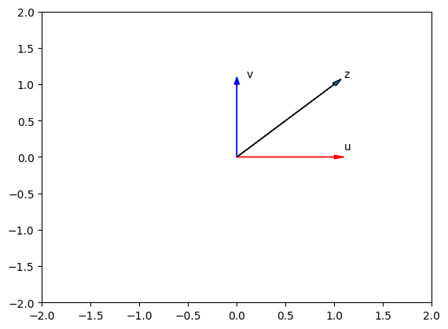

```python
# Numpy massivlarini grafikda chizish

Plotvec1(u, z, v)
```

### O‘zingiz sinab ko‘ring

Berilgan arr1 va arr2 numpy massivlari ustida qo‘shish amalini bajaring:

```python
arr1 = np.array([10, 11, 12, 13, 14, 15])
arr2 = np.array([20, 21, 22, 23, 24, 25])

# Kodni shu yerga yozing
```

**Yechimni ko‘rish uchun bu yerni bosing**

```
arr3 = np.add(arr1, arr2)
arr3
```

Numpy massivi `a` ni ko'rib chiqamiz:

```python
a = np.array([10, 20, 30])
a
```

```
array([10, 20, 30])
```

Numpy massivi `b` ni ko'rib chiqamiz:

```python
b = np.array([5, 10, 15])
b
```

```
array([ 5, 10, 15])
```

Biz ikkita massivni ayirishimiz va natijani `c` ga o'zlashtirishimiz mumkin:

```python
c = np.subtract(a, b)

print(c)
```

```
[ 5 10 15]
```

### O‘zingiz sinab ko‘ring

Berilgan arr1 va arr2 numpy massivlari ustida ayirish amalini bajaring:

```python
arr1 = np.array([10, 20, 30, 40, 50, 60])
arr2 = np.array([20, 21, 22, 23, 24, 25])

# Kodni shu yerga yozing
```

**Yechimni ko‘rish uchun bu yerni bosing**

```
arr3 = np.subtract(arr1, arr2)
arr3
```

### Massivlarni ko'paytirish

Numpy vektor massivi `y` ni ko'rib chiqing:

```python
# Numpy massivini yaratish

x = np.array([1, 2])
x
```

```
array([1, 2])
```

```python
# Numpy massivini yaratish

y = np.array([2, 1])
y
```

```
array([2, 1])
```

```python
# Numpy massivlarini ko'paytirish

z = np.multiply(x, y)
z
```

```
array([2, 2])
```

### O‘zingiz sinab ko‘ring

Berilgan arr1 va arr2 numpy massivlari ustida ko‘paytirish amalini bajaring:

```python
arr1 = np.array([10, 20, 30, 40, 50, 60])
arr2 = np.array([2, 1, 2, 3, 4, 5])

# Kodni shu yerga yozing
```

**Yechimni ko‘rish uchun bu yerni bosing**

```
arr3 = np.multiply(arr1, arr2)
arr3
```

### Massivlarni bo'lish

Numpy vektor massivi `a` ni ko'rib chiqing:

```python
a = np.array([10, 20, 30])
a
```

```
array([10, 20, 30])
```

Numpy vektor massivi `b` ni ko'rib chiqing:

```python
b = np.array([2, 10, 5])
b
```

```
array([ 2, 10,  5])
```

Biz ikkita massivni bo'lishimiz va natijani `c` ga o'zlashtirishimiz mumkin:

```python
c = np.divide(a, b)
c
```

```
array([5., 2., 6.])
```

### O‘zingiz sinab ko‘ring

Berilgan arr1 va arr2 numpy massivlari ustida bo‘lish amalini bajaring:

```python
arr1 = np.array([10, 20, 30, 40, 50, 60])
arr2 = np.array([3, 5, 10, 8, 2, 33])

# Kodni shu yerga yozing
```

**Yechimni ko‘rish uchun bu yerni bosing**

```
arr3 = np.divide(arr1, arr2)
arr3
```

### Skalyar ko'paytma

```python
X = np.array([1, 2])
Y = np.array([3, 2])
```

```python
# Skalyar ko'paytmani hisoblash

np.dot(X, Y)
```

```
np.int64(7)
```

```python
# X ning elementlari
print(X[0])
print(X[1])
```

```
1
2
```

```python
# Y ning elementlari
print(Y[0])
print(Y[1])
```

```
3
2
```

Biz quyida ko'rsatilganidek skalyar ko'paytmani bajaryapmiz:

[figure not shown]

### O‘zingiz sinab ko‘ring

Berilgan arr1 va arr2 numpy massivlari ustida skalyar ko‘paytirish (dot) amalini bajaring:

```python
arr1 = np.array([3, 5])
arr2 = np.array([2, 4])

# Kodni shu yerga yozing
```

**Yechimni ko‘rish uchun bu yerni bosing**

```
arr3 = np.dot(arr1, arr2)
arr3
```

### Numpy massiviga o'zgarmas son qo'shish

Quyidagi massivni ko'rib chiqing:

```python
# Numpy massiviga o'zgarmas son (constant) qo'shish

u = np.array([1, 2, 3, -1])
u
```

```
array([ 1,  2,  3, -1])
```

Massivning har bir elementiga 1 o‘zgarmas sonini qo‘shish:

```python
# Massivga o'zgarmas sonni qo'shish

u + 1
```

```
array([2, 3, 4, 0])
```

Jarayon quyidagi animatsiyada umumlashtirilgan:

[figure not shown]

### O‘zingiz sinab ko‘ring

Berilgan `arr` numpy massivining har bir elementiga 5 o‘zgarmas sonini qo‘shing:

```python
arr = np.array([1, 2, 3, -1])

# Kodni shu yerga yozing
```

**Yechimni ko‘rish uchun bu yerni bosing**

```
arr + 5
```

## Matematik funksiyalar

Numpy-da `pi` qiymatini quyidagicha olishimiz mumkin:

```python
# pi qiymati

np.pi
```

```
3.141592653589793
```

Biz quyidagi numpy massivini radianlarda yaratishimiz mumkin:

```python
# Radianlarda numpy massivini yaratish

x = np.array([0, np.pi/2 , np.pi])
```

Biz `sin` funksiyasini `x` massiviga qo'llashimiz va qiymatlarni `y` massiviga o'zlashtirishimiz mumkin; bu massivning har bir elementiga sinus funksiyasini qo'llaydi:

```python
# Har bir elementning sinusini hisoblash

y = np.sin(x)
y
```

```
array([0.0000000e+00, 1.0000000e+00, 1.2246468e-16])
```

## Linspace

Matematik funksiyalarni chizish uchun foydali funksiya `linspace` hisoblanadi. Linspace belgilangan interval bo'yicha bir xil masofadagi sonlarni qaytaradi.

**numpy.linspace(start, stop, num = int value)**

start : interval oralig'ining boshi

stop : interval oralig'ining oxiri

num : hosil qilinadigan namunalar soni

```python
# [-2, 2] oralig'ida 5 ta elementdan iborat numpy massivini yaratish

np.linspace(-2, 2, num=5)
```

```
array([-2., -1.,  0.,  1.,  2.])
```

Agar biz `num` parametrini 9 ga o'zgartirsak, -2 dan 2 gacha bo'lgan oraliqda bir xil masofada joylashgan 9 ta sonni olamiz:

```python
# [-2, 2] oralig'ida 9 ta elementdan iborat numpy massivini yaratish

np.linspace(-2, 2, num=9)
```

```
array([-2. , -1.5, -1. , -0.5,  0. ,  0.5,  1. ,  1.5,  2. ])
```

Biz `linspace` funksiyasidan 0 dan 2π gacha bo‘lgan oraliqda bir xil masofada joylashgan 100 ta namunani yaratish uchun foydalanishimiz mumkin:

```python
# [0, 2π] oralig'ida 100 ta elementdan iborat numpy massivini yaratish

x = np.linspace(0, 2*np.pi, num=100)
```

Biz `sin` funksiyasini `x` massivining har bir elementiga qo'llashimiz va uni `y` massiviga o'zlashtirishimiz mumkin:

```python
# x ro'yxatining sinusini hisoblash

y = np.sin(x)
```

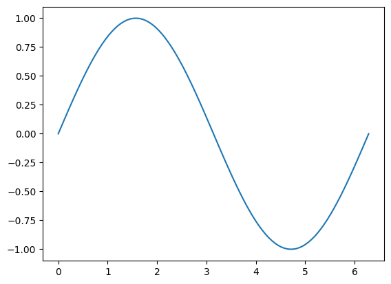

```python
# Natijani chizish

plt.plot(x, y)
```

### O‘zingiz sinab ko‘ring

[5, 4] oralig'ida 6 ta elementdan iborat numpy massivini yarating:

```python
# Kodni shu yerga yozing
```

**Yechimni ko‘rish uchun bu yerni bosing**

```
np.linspace(5, 4, num=6)
```

### 1D massivlarni iteratsiya qilish (takrorlash)

Iteratsiya qilish — bu elementlarni birma-bir ko‘rib chiqish deganidir.

Agar biz 1D (bir o‘lchovli) massivni iteratsiya qilsak, u har bir element orqali tartib bilan o‘tadi.

Numpy massivini bevosita chiqarganimizda, u massiv (array) formatida ko'rinadi:

```python
arr1 = np.array([1, 2, 3])
print(arr1)
```

```
[1 2 3]
```

Ammo natijani ro‘yxat (list) shaklida yoki elementma-element olishni istasangiz, `for` siklidan foydalanishingiz mumkin:

```python
for x in arr1:
  print(x)
```

```
1
2
3
```

## 1D Numpy massivlari bo‘yicha viktorina

Numpyda quyidagi vektor ayirmasini amalga oshiring: `u - v`

```python
# Pastga kodni yozing va bajarish uchun Shift+Enter tugmalarini bosing

u = np.array([1, 0])
v = np.array([0, 1])
```

**Yechimni ko‘rish uchun bu yerni bosing**

```
u - v
```

z numpy massivini -2 ga ko‘paytiring:

```python
# Kodni pastga yozing va bajarish uchun Shift+Enter tugmalarini bosing

z = np.array([2, 4])
```

**Yechimni ko‘rish uchun bu yerni bosing**

```
-2 * z
```

`[1, 2, 3, 4, 5]` va `[1, 0, 1, 0, 1]` ro'yxatlarini ko'rib chiqing. Ikkala ro'yxatni numpy massiviga o'tkazing, so'ngra ularni bir-biriga ko'paytiring:

```python
# Kodni pastga yozing va bajarish uchun Shift+Enter tugmalarini bosing
```

**Yechimni ko‘rish uchun bu yerni bosing**

```
a = np.array([1, 2, 3, 4, 5])
b = np.array([1, 0, 1, 0, 1])
a * b
```

```python
# Import the libraries

import time
import sys
import numpy as np

import matplotlib.pyplot as plt


def Plotvec2(a,b):
    ax = plt.axes()# to generate the full window axes
    ax.arrow(0, 0, *a, head_width=0.05, color ='r', head_length=0.1)#Add an arrow to the  a Axes with arrow head width 0.05, color red and arrow head length 0.1
    plt.text(*(a + 0.1), 'a')
    ax.arrow(0, 0, *b, head_width=0.05, color ='b', head_length=0.1)#Add an arrow to the  b Axes with arrow head width 0.05, color blue and arrow head length 0.1
    plt.text(*(b + 0.1), 'b')
    plt.ylim(-2, 2)#set the ylim to bottom(-2), top(2)
    plt.xlim(-2, 2)#set the xlim to left(-2), right(2)
```

`[-1, 1]` va `[1, 1]` ro'yxatlarini `a` va `b` numpy massivlariga o'tkazing. So'ngra, `Plotvec2` funksiyasi yordamida massivlarni vektorlar sifatida chizing va ularning skalyar ko'paytmasini (dot product) toping:

```python
# Kodni pastga yozing va bajarish uchun Shift+Enter tugmalarini bosing
```

**Yechimni ko‘rish uchun bu yerni bosing**

```
a = np.array([-1, 1])
b = np.array([1, 1])
Plotvec2(a, b)
print("The dot product is", np.dot(a,b))
```

`[1, 0]` va `[0, 1]` ro'yxatlarini `a` va `b` numpy massivlariga o'tkazing. So'ngra, `Plotvec2` funksiyasi yordamida massivlarni vektorlar sifatida chizing va ularning skalyar ko'paytmasini (dot product) toping:

```python
# Kodingizni pastga yozing va bajarish uchun Shift+Enter tugmalarini bosing
```

**Yechimni ko‘rish uchun bu yerni bosing**

```
a = np.array([1, 0])
b = np.array([0, 1])
Plotvec2(a, b)
print("The dot product is", np.dot(a, b))
```

`[1, 1]` va `[0, 1]` ro'yxatlarini `a` va `b` numpy massivlariga o'tkazing. So'ngra, `Plotvec2` funksiyasi yordamida massivlarni vektorlar sifatida chizing va ularning skalyar ko'paytmasini (dot product) toping:

```python
# Kodni pastga yozing va bajarish uchun Shift+Enter tugmalarini bosing
```

**Yechimni ko‘rish uchun bu yerni bosing**

```
a = np.array([1, 1])
b = np.array([0, 1])
Plotvec2(a, b)
print("The dot product is", np.dot(a, b))
```

Nega `[-1, 1]` va `[1, 1]` vektorlarining skalyar ko'paytmasi hamda `[1, 0]` va `[0, 1]` vektorlarining skalyar ko'paytmasi natijalari nolga teng, ammo `[1, 1]` va `[0, 1]` uchun esa nol emas?

*Yordam: Tegishli chizmalarni o'rganing, ko'rsatkichlar (strelkalar) qaysi yo'nalishga qarab turganiga e'tibor bering.*

```python
# Kodni pastga yozing va bajarish uchun Shift+Enter tugmalarini bosing
```

**Yechimni ko‘rish uchun bu yerni bosing**

```
The vectors used for question 4 and 5 are perpendicular. As a result, the dot product is zero.
```

`[1, 2, 3]` va `[8, 9, 10]` ro‘yxatlarini `arr1` va `arr2` numpy massivlariga o‘tkazing. So‘ngra `arr1` va `arr2` ustida **Qo‘shish** (Addition), **Ayirish** (Subtraction), **Ko‘paytirish** (Multiplication), **Bo‘lish** (Division) va **Skalyar ko‘paytma** (Dot Operation) amallarini bajaring.

```python
# Kodni pastga yozing va bajarish uchun Shift+Enter tugmalarini bosing
```

**Yechimni ko‘rish uchun bu yerni bosing**

```
arr1 = np.array([1, 2, 3])
arr2 = np.array([8, 9, 10])

arr3 = np.add(arr1, arr2)
arr3

arr4 = np.subtract(arr1, arr2)
arr4

arr5 = np.multiply(arr1, arr2)
arr5


arr6 = np.divide(arr1, arr2)
arr6

arr7 = np.dot(arr1, arr2)
arr7
```

`[1, 2, 3, 4, 5]` va `[6, 7, 8, 9, 10]` ro‘yxatlarini `arr1` va `arr2` numpy massivlariga o‘tkazing. So‘ngra `arr1` va `arr2` massivlaridan juft va toq sonlarni toping:

```python
# Kodni pastga yozing va bajarish uchun Shift+Enter tugmalarini bosing
```

**Yechimni ko‘rish uchun bu yerni bosing**

```
arr1 = np.array([1, 2, 3, 4, 5])
arr2 = np.array([6, 7, 8, 9, 10])

#Starting index in slice is 1 as first even element(2) in array1 is at index 1
even_arr1 = arr1[1:5:2]
print("even for array1",even_arr1)

#Starting index in slice is 0 as first odd element(1) in array1 is at index 0
odd_arr1=arr1[0:5:2]
print("odd for array1",odd_arr1)

#Starting index in slice is 0 as first even element(6) in array2 is at index 0
even_arr2 = arr2[0:5:2]
print("even for array2",even_arr2)


#Starting index in slice is 1 as first odd element(7) in array2 is at index 1
odd_arr2=arr2[1:5:2]
print("odd for array2",odd_arr2)
```

## Oxirgi mashq!

Tabriklaymiz, siz Python bo'yicha birinchi darsingizni va amaliy mashg'ulotingizni muvaffaqiyatli yakunladingiz.